# Delphi's COVIDcast Project: Tools for Comprehensive Evaluation of Forecasters

Jacob Bien  
Data Science and Operations  
University of Southern California

[figure not shown]

[figure not shown]

September 29, 2020

# COVIDcast

The COVIDcast project has many parts:

1. Unique relationships with partners in tech and healthcare granting us to access to data on pandemic activity
2. Code and infrastructure to build COVID-19 indicators, continuously-updated and geographically comprehensive
3. A historical database of all indicators, including revision tracking, with over 500 million observations
4. A [public API](https://cmu-delphi.github.io/delphi-epidata/api/covidcast.html) serving new indicators daily (and [R and Python packages](https://cmu-delphi.github.io/delphi-epidata/api/covidcast_clients.html) for client support)
5. [Interactive maps and graphics](https://covidcast.cmu.edu) to display our indicators
6. Forecasting and modeling work building on the indicators

# This Talk

Today: How to evaluate forecaster performance?

- The newest Delphi R package: evalcast
- Handling backfill
- Some favorite plots and error measures
- Mixed effects model for comparing forecasters

Reproducible talk: all code included

# evalcast R package

Currently sitting on a branch of our public [covidcast GitHub repo](https://github.com/cmu-delphi/covidcast/)

You can install it with:

```r
devtools::install_github("cmu-delphi/covidcast", ref = "evalcast",
                         subdir = "R-packages/evalcast")
```

Important: evalcast package builds on our [covidcast R package](https://cmu-delphi.github.io/covidcast/covidcastR/)

# Using evalcast in 3 Steps

**Step #1.** Run your forecaster to create a predictions card.

- Define `signals`: Which [COVIDcast signals](https://cmu-delphi.github.io/delphi-epidata/api/covidcast_signals.html) will your forecaster use?

```r
signals <- tibble(data_source = "jhu-csse",
                  signal = c("deaths_incidence_num", "confirmed_incidence_num"),
                  start_day = "2020-06-15")
```

- Use `evalcast::get_predictions()` to define the task and run your forecaster.

```r
library(evalcast)
# input the forecaster and define the exact task
predictions_cards <- get_predictions(
  baseline_forecaster, # put your forecaster here
  name_of_forecaster = "baseline", # give it a name
  signals, # with what data?
  forecast_dates = c("2020-07-20", "2020-07-27"), # on what days?
  incidence_period = "epiweek", # over what period?
  ahead = 3, # at what horizon?
  geo_type = "state" # at what geographic scale?
  )
```

# Using evalcast in 3 Steps (Cont.)

**Step #1.** Run your forecaster to create a predictions card.

23 quantiles at every location ...

```r
predictions_cards[[1]] # first of two dates
```

```
## # A tibble: 52 x 2
##    location forecast_distribution
##  * <chr>    <list>
##  1 01       <tibble [23 × 2]>
##  2 02       <tibble [23 × 2]>
##  3 04       <tibble [23 × 2]>
##  4 05       <tibble [23 × 2]>
##  5 06       <tibble [23 × 2]>
##  6 08       <tibble [23 × 2]>
##  7 09       <tibble [23 × 2]>
##  8 10       <tibble [23 × 2]>
##  9 11       <tibble [23 × 2]>
## 10 12       <tibble [23 × 2]>
## # … with 42 more rows
```

# Using evalcast in 3 Steps (Cont.)

**Step #1.** Run your forecaster to create a predictions card.

23 quantiles in Alabama ...

```r
predictions_cards[[1]]$forecast_distribution[[1]] # Alabama
```

```
## # A tibble: 23 x 2
##    probs quantiles
##    <dbl>     <dbl>
##  1 0.01       214.
##  2 0.025      214.
##  3 0.05       215.
##  4 0.1        215.
##  5 0.15       216.
##  6 0.2        217.
##  7 0.25       218.
##  8 0.3        218
##  9 0.35       218
## 10 0.4        218
## # … with 13 more rows
```

# Using evalcast in 3 Steps (Cont.)

**Step #2.** Create a score card.

- Define some error measures (or use our defaults)
- Run `evalcast::evaluate_predictions()` to generate your forecaster's score card.

```r
scorecard <- evaluate_predictions(predictions_cards, backfill_buffer = 10)
```

# Using evalcast in 3 Steps (Cont.)

**Step #3.** Analyze forecaster performance.

- Make plots
- Compare forecasters across locations and times

(Examples coming later)

# Why Does `evalcast::get_predictions()` Run the Forecaster?

- Couldn't we just let the user produce the predictions card?
- For accurate evaluation, need to account for data revisions ... see COVIDcast API slides

# Example: Backfill in Doctor's Visits Signal

The last two weeks of August in CA ...

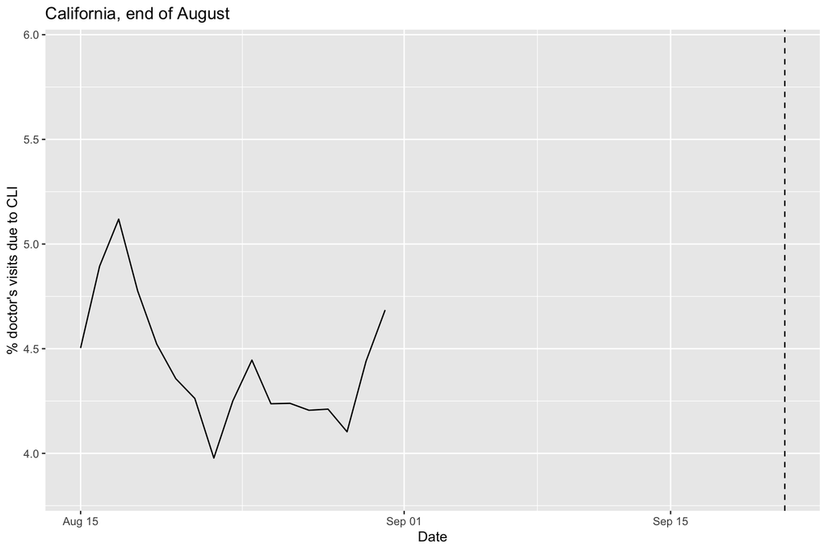

```r
# Let's get the data that was available as of 9/21 about the last two weeks
# of August in CA:
dv <- covidcast_signal(data_source = "doctor-visits",
                      signal = "smoothed_adj_cli",
                      start_day = "2020-08-15",
                      end_day = "2020-08-31",
                      geo_type = "state",
                      geo_values = "ca",
                      as_of = "2020-09-21")
ggplot(dv, aes(x = time_value, y = value)) +
  geom_line() +
  xlim(as.Date("2020-08-15", origin = "1970-01-01"),
       as.Date("2020-09-21", origin = "1970-01-01")) +
  ylim(3.83, 5.92) +
  geom_vline(aes(xintercept = as.Date("2020-09-21", origin = "1970-01-01")),
             lty = 2) +
  labs(x = "Date", y = "% doctor's visits due to CLI",
       title = "California, end of August") +
  theme(legend.pos = "bottom")
```

# Example: Backfill in Doctor's Visits Signal (Cont.)

The last two weeks of August in CA ...

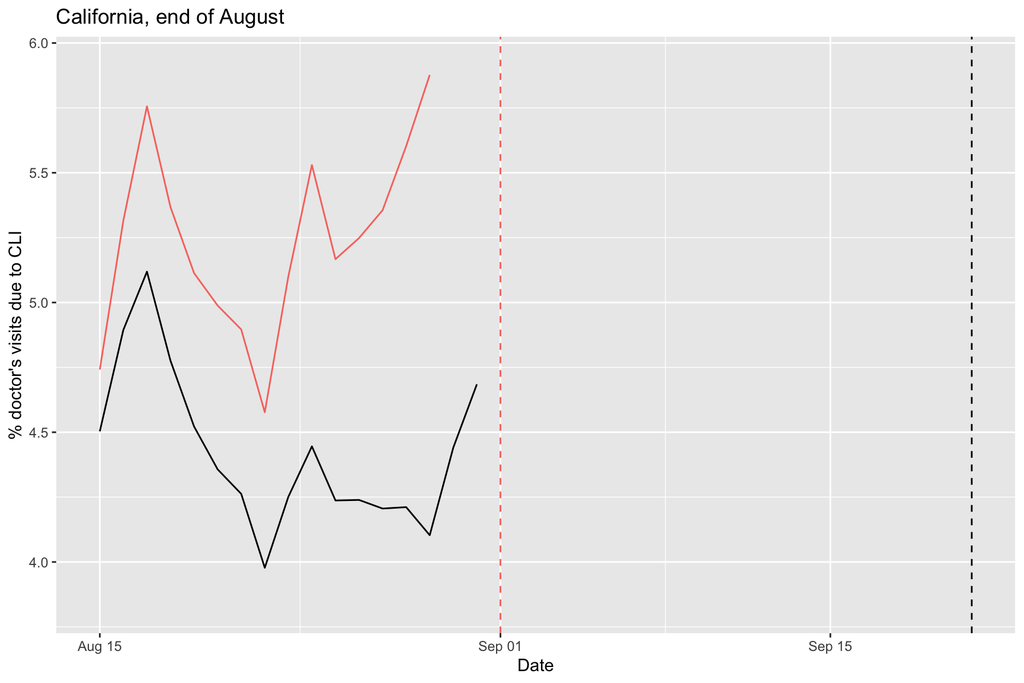

```r
# Loop over "as of" dates, fetch data from the API for each one
as_ofs = seq(as.Date("2020-09-01"), as.Date("2020-09-21"), length = 6)[-6]
dv_as_of = map_dfr(as_ofs, function(as_of) {
  covidcast_signal(data_source = "doctor-visits", signal = "smoothed_adj_cli",
                   start_day = "2020-08-15", end_day = "2020-08-31",
                   geo_type = "state", geo_values = "ca", as_of = as_of)
})
# Now plot the each "as of" time series curve
dv_as_of %>%
  filter(issue == as.Date("2020-09-01")) %>%
  ggplot(aes(x = time_value, y = value)) +
  geom_line(aes(color = factor(issue))) +
  geom_vline(aes(color = factor(issue), xintercept = issue), lty = 2) +
  xlim(as.Date("2020-08-15", origin = "1970-01-01"),
       as.Date("2020-09-21", origin = "1970-01-01")) +
  ylim(3.83, 5.92) +
  labs(color = "as of", x = "Date", y = "% doctor's visits due to CLI",
       title = "California, end of August") +
  geom_line(data = dv, aes(x = time_value, y = value)) +
  geom_vline(aes(xintercept = as.Date("2020-09-21", origin = "1970-01-01")),
             lty = 2) +
  theme(legend.pos = "none")
```

# Example: Backfill in Doctor's Visits Signal (Cont.)

The last two weeks of August in CA ...

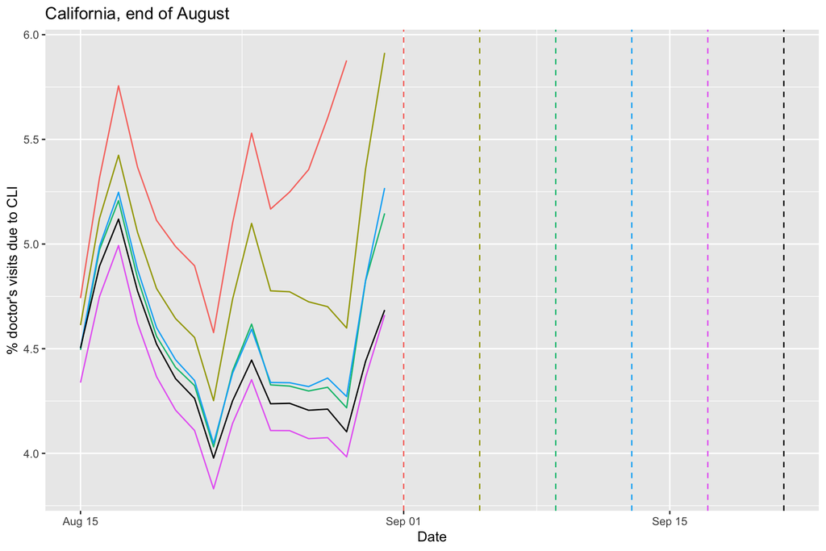

```r
# Loop over "as of" dates, fetch data from the API for each one
as_ofs = seq(as.Date("2020-09-01"), as.Date("2020-09-21"), length = 6)[-6]
dv_as_of = map_dfr(as_ofs, function(as_of) {
  covidcast_signal(data_source = "doctor-visits", signal = "smoothed_adj_cli",
                   start_day = "2020-08-15", end_day = "2020-08-31",
                   geo_type = "state", geo_values = "ca", as_of = as_of)
})
# Now plot the each "as of" time series curve
dv_as_of %>%
  ggplot(aes(x = time_value, y = value)) +
  geom_line(aes(color = factor(issue))) +
  geom_vline(aes(color = factor(issue), xintercept = issue), lty = 2) +
  xlim(as.Date("2020-08-15", origin = "1970-01-01"),
       as.Date("2020-09-21", origin = "1970-01-01")) +
  ylim(3.83, 5.92) +
  labs(color = "as of", x = "Date", y = "% doctor's visits due to CLI",
       title = "California, end of August") +
  geom_line(data = dv, aes(x = time_value, y = value)) +
  geom_vline(aes(xintercept = as.Date("2020-09-21", origin = "1970-01-01")),
             lty = 2) +
  theme(legend.pos = "none")
```

# Implications for Forecasting and Evaluation

1. In backtesting, we should provide the forecaster the data that would have been available as of the forecast date. Otherwise, performance assessment may be naively optimistic.
2. Trained forecasters that do not account for backfill may learn to rely too heavily on recent data.
3. Evaluation relies on the "actual outcome", but this might not be reliably known until some time has passed.

Note: `evalcast::evaluate_predictions()` has a `backfill_buffer` parameter that forces one to wait a certain amount of time before trying to evaluate.

# Evaluation Plots

- User can define any error measure
- A few are built-in

```r
err_measures <- list(ae = absolute_error,
                     wis = weighted_interval_score,
                     coverage_80 = interval_coverage(alpha = 0.2))
```

For more on weighted interval score, see, for example, [Bracher et al. (2020)](https://arxiv.org/pdf/2005.12881.pdf).

# Comparing COVID Hub Forecasters

`evalcast::get_covidhub_predictions()` grabs data submitted to [reichlab/covid19-forecast-hub](https://github.com/reichlab/covid19-forecast-hub/tree/master/data-processed).

```r
forecast_dates <- seq(lubridate::ymd("2020-08-03"),
                      lubridate::ymd("2020-08-17"), by = 7)
CH_baseline <- get_covidhub_predictions("COVIDhub-baseline",
                                        forecast_dates,
                                        ahead = 3,
                                        geo_type = "state",
                                        response_signal = "deaths_incidence_num")
CH_ensemble <- get_covidhub_predictions("COVIDhub-ensemble",
                                        forecast_dates,
                                        ahead = 3,
                                        geo_type = "state",
                                        response_signal = "deaths_incidence_num")
scorecard_CH_baseline <- evaluate_predictions(CH_baseline)[[1]]
scorecard_CH_ensemble <- evaluate_predictions(CH_ensemble)[[1]]
scorecards <- list(scorecard_CH_baseline, scorecard_CH_ensemble)
```

# Absolute Error

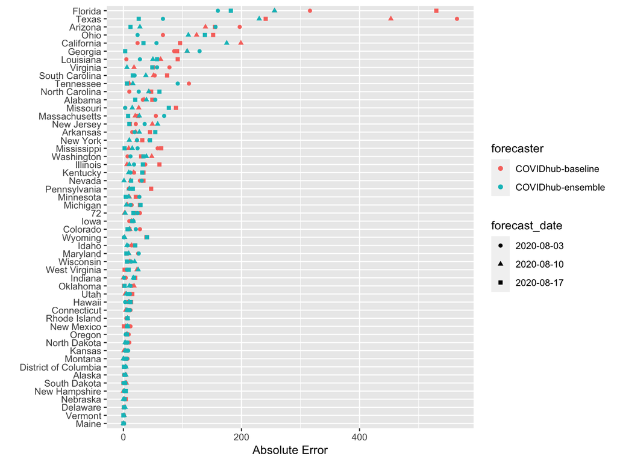

```r
plot_measure(scorecards, err_name = "ae", type = "dotplot") +
  labs(x = "Absolute Error", y = "")
```

# Weighted Interval Score

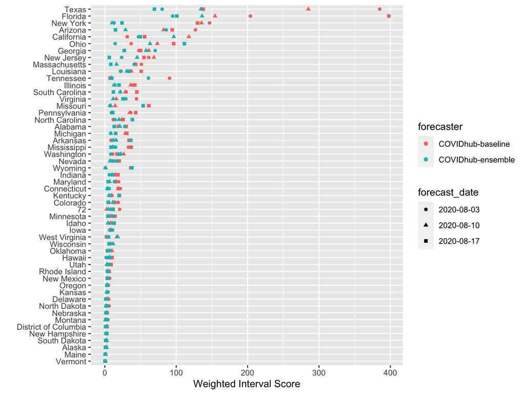

```r
plot_measure(scorecards, err_name = "wis", type = "dotplot") +
  labs(x = "Weighted Interval Score", y = "")
```

# Interval Coverage

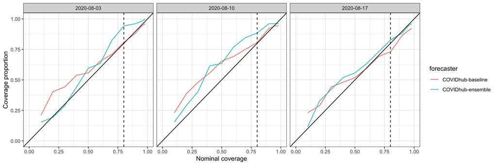

```r
plot_coverage(scorecards)
```

# Calibration

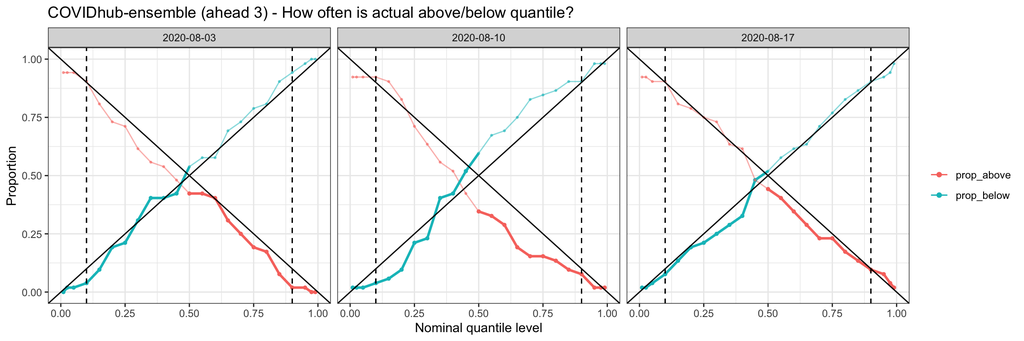

```r
plot_calibration(scorecard_CH_ensemble, type = "wedgeplot")
```

# Proportion Above/Below

A miscalibrated 80% interval

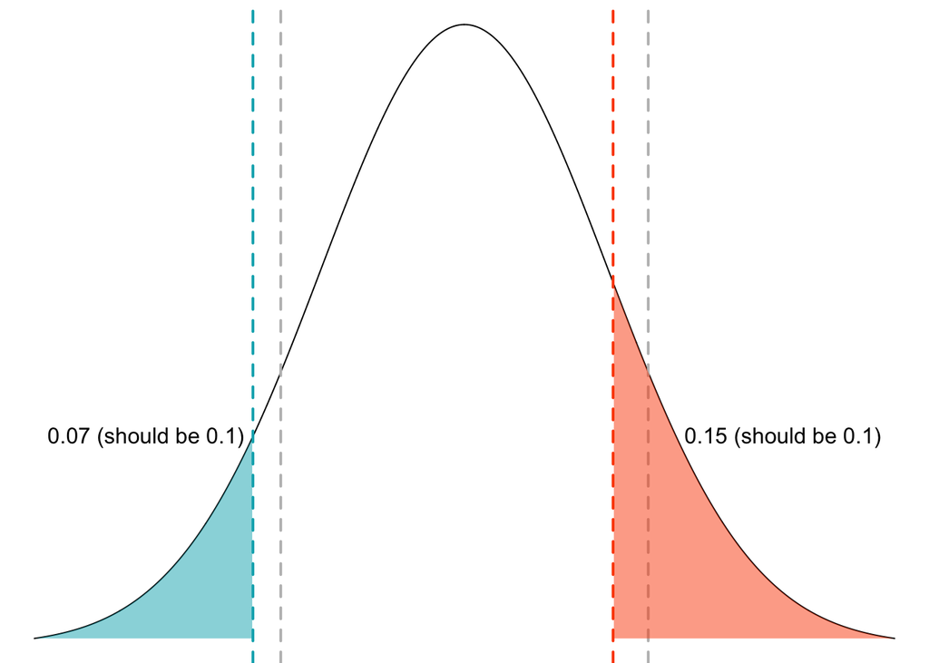

```r
# Blue, red (similar to ggplot defaults)
ggplot_colors = c("#00AFBB", "#FC4E07")
x = seq(-3, 3, length = 1000)
y = dnorm(x)
q1 = qnorm(0.1); q1_hat = qnorm(0.07)
q2 = qnorm(0.9); q2_hat = qnorm(0.85)
par(mar = c(0,0,0,0))
plot(x, dnorm(x), type = "l", axes = FALSE)
abline(v = c(q1, q2), lwd = 2, lty = 2, col = "gray")
abline(v = c(q1_hat, q2_hat), lwd = 2, lty = 2, col = ggplot_colors)
polygon(c(x[x < q1_hat], max(x[x < q1_hat])),
        c(y[x < q1_hat], min(y[x < q1_hat])),
        col = adjustcolor(ggplot_colors[1], alpha.f = 0.5), border = NA)
polygon(c(min(x[x > q2_hat]), x[x > q2_hat]),
        c(min(y[x > q2_hat]), y[x > q2_hat]),
        col = adjustcolor(ggplot_colors[2], alpha.f = 0.5), border = NA)
text(min(x), max(y[x < q1_hat]), labels = "0.07 (should be 0.1)", pos = 4)
text(max(x), max(y[x < q1_hat]), labels = "0.15 (should be 0.1)", pos = 2)
```

*Image credit: Ryan Tibshirani*

# Interval Width

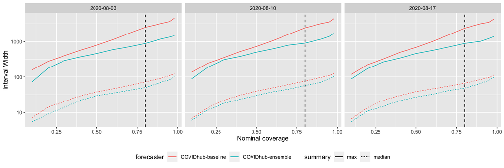

```r
plot_width(scorecards) + scale_y_log10() + theme(legend.pos = "bottom")
```

# Do We Have Evidence That One Forecaster Is Better than Another?

- **Challenge:** Dependence induced by common locations and common forecast dates
- **Approach:** Mixed effects models for forecaster comparison based on an error measure $E_{\ell t f}$
- For example, $E_{\ell tf} = \log(\text{Absolute Error}_{\ell tf})$

$$E_{\ell tf} = \mu + \alpha_f + a_\ell + b_t + \epsilon_{\ell tf},$$

- Location-specific random effects $a_\ell$, time-specific random effects $b_t$, expected baseline performance $\mu$
- Forecaster-specific fixed effects $\alpha_f$ are of primary interest. For example, is $\alpha_f>0$?
- Coming soon to evalcast!

# Example: Comparing Forecasters to the COVIDhub-baseline

Fit mixed effects model on 5 methods (using 9 forecast dates): - Three long-running forecasters on the COVID Hub (let's call them F1, F2, F3) - COVIDhub-Ensemble - COVIDhub-baseline - we'll choose this as the baseline

```r
library(lme4)
load("talk_files/scorecard_df.Rdata")
fit <- lmer(log(1 + ae) ~ forecaster + (1|location) + (1|forecast_date),
            data = sc_df)
```

```r
confint(fit) %>%
  as_tibble(rownames = "var") %>%
  filter(str_starts(var, "forecaster"))
```

```
## # A tibble: 4 x 3
##   var                         `2.5 %` `97.5 %`
##   <chr>                         <dbl>    <dbl>
## 1 forecasterCOVIDhub-ensemble -0.359   -0.134
## 2 forecasterF1                 0.0363   0.265
## 3 forecasterF2                -0.251   -0.0258
## 4 forecasterF3                 0.0313   0.257
```

- Evidence that F2 and COVIDhub-ensemble outperform baseline in absolute error; F1 and F3 appear to underperform

# Thanks

- The [whole Delphi team](https://covidcast.cmu.edu/covid19-response-team.html), and various CMU units
- Especially: Alden Green, Balasubramanian Narasimhan, Samyak Rajanala, Rob Tibshirani, Ryan Tibshirani
- Reich Lab
- Centers for Disease Control and Prevention

You can find the evalcast R package source [here](https://github.com/cmu-delphi/covidcast/tree/evalcast/R-packages/evalcast)

[figure not shown]

[figure not shown]